# Analyzing NBA Player Performance Over Time

Daniela Nieto, Leopoldo Nikonowicz

August 3, 2023

## Introduction:

- Player: The name of the player
- Team Name: The name of the NBA team the player is a part of.
- Ranking: The player’s ranking during the respective season.
- Points: The total points scored by the player during the season.
- Field Goals (FG): The number of successful field goals made by the player.
- Field Goal Attempts (FGA): The total number of field goal attempts by the player.
- 2-Point Field Goals (2P): The number of successful two-point field goals made.
- 2-Point Field Goal Attempts (2PA): The total number of two-point field goal attempts.
- Free Throws (FT): The number of successful free throws made.
- Assists (AST): The total assists made by the player.
- Fouls (FL): The total number of fouls committed by the player.
- Rebounds (REB): The total number of rebounds grabbed by the player.

The NBA per-game statistics dataset is a valuable resource for understanding players performance and trends over the past decades. The data needs to be collected from sports databases. The source for the NBA per-game statistics dataset is the following:

- https://www.basketball-reference.com/leagues/NBA_2023_per_game.html

We will gather per-game statistics from the cited source covering seasons from 1946 to 2023. The data needs to be compiled and a new column for the corresponding season year will be added to facilitate analysis. The dataset will contain a total of 31 variables. There are about 200-600 players per season. Once the data is compiled, we will be able to meet the 2,000-observation threshold.

Our interest in this dataset is driven by our passion for sports, particularly basketball, and our curiosity about how players performances have evolved over time. By analyzing the data, we aim to gain insights into the patterns and correlations that determine players performance. We believe that understanding the factors influencing rankings can provide valuable insights for coaches, analysts, and team managers in optimizing strategies, player selection, and overall team development.

## Methods:

```r
library(faraway)
library(lmtest)
library(leaps)
library(ggplot2)
library(readr)
```

### Functions:

```r
plot_model = function(model, pointcol = "dodgerblue", linecol = "darkorange") {
  par(mfrow = c(1, 2))
  plot(fitted(model), resid(model),
       col = pointcol, pch = 20, cex = 1.5,
       xlab = "Fitted", ylab = "Residuals")
  abline(h = 0, col = linecol, lwd = 2)

  qqnorm(resid(model), col = pointcol, pch = 20, cex = 1.5)
  qqline(resid(model), col = linecol, lwd = 2)
}

get_num_params = function(model) {
  length(coef(model))
}

get_loocv_rmse = function(model) {
  sqrt(mean((resid(model) / (1 - hatvalues(model))) ^ 2))
}

get_adj_r2 = function(model) {
  summary(model)$adj.r.squared
}
```

### Data Loading and Cleaning:

*Load data and Modified names*

Before constructing predictive models, we performed data preprocessing to ensure the reliability and relevance of our analysis. We loaded the dataset and modified variable names to enhance usability. This step was crucial in preventing naming conflicts and making the dataset more manageable for subsequent analysis. We also addressed collinearity issues by identifying and removing correlated variables, such as various field goal percentages and attempts. For instance, we removed variables like field goal percentage (FGP), three-point percentage (ThreePP), and free-throw percentage (FTP), which exhibited collinearity with other variables. Missing values were handled by removing corresponding rows, ensuring that our analysis was conducted on a complete and representative subset of the data.

*Modified names*

```r
nba = read_csv("NBA_data.csv")

names(nba)[names(nba) == "3P"] = "ThreeP"
names(nba)[names(nba) == "3PA"] = "ThreePA"
names(nba)[names(nba) == "3P%"] = "ThreePP"

names(nba)[names(nba) == "2P"] = "TwoP"
names(nba)[names(nba) == "2PA"] = "TwoPA"
names(nba)[names(nba) == "2P%"] = "TwoPP"

names(nba)[names(nba) == "FG%"] = "FGP"
names(nba)[names(nba) == "eFG%"] = "eFGP"
names(nba)[names(nba) == "FT%"] = "FTP"
raw_nba = nba
```

The purpose of this was to assess the data for collinearity issues, with additional examples provided in the appendix.

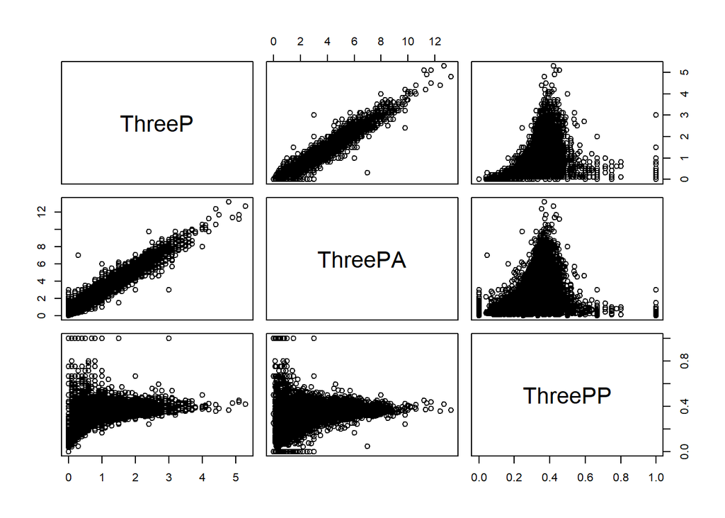

```r
three_pointers = nba[, c("ThreeP", "ThreePA", "ThreePP")]
pairs(three_pointers)
```

```r
nba = nba[, -which(names(nba) == "Player"| names(nba) == "Pos" | names(nba) == "Tm" |
                      names(nba) == "FGP" | names(nba) == "FGA" | names(nba) == "ThreePP" | names(nba) == "ThreePA" |
                      names(nba) == "TwoPP" | names(nba) == "TwoPA" | names(nba) == "FTP"|
                      names(nba) == "FTA" | names(nba) == "ORB" | names(nba) == "DRB")]

# Remove rows with missing values
cleaned_nba = na.omit(nba)
cleaned_nba = cleaned_nba[cleaned_nba$PTS != 0, ]
cleaned_nba = cleaned_nba[cleaned_nba$eFGP < 1 & cleaned_nba$eFGP > 0, ]
```

### Models:

*BACK BIC*

```r
# Create large model
large_model = lm(PTS ~ ., data = cleaned_nba)

n = nrow(cleaned_nba)

# Perform backward stepwise selection
back_bic = step(large_model, k = log(n), trace = 0)
vif(back_bic)
```

```
##        G       FG   ThreeP     TwoP       FT
##    1.358 2707.958  269.571 2166.592    3.701
```

```r
back_bic = lm(PTS ~ G + FG + FT, data = cleaned_nba)
vif(back_bic)
```

```
##     G    FG    FT
## 1.357 3.980 3.555
```

*Interaction Model*

```r
int_model = lm(PTS ~ G * FG * FT, data = cleaned_nba)
```

## Results

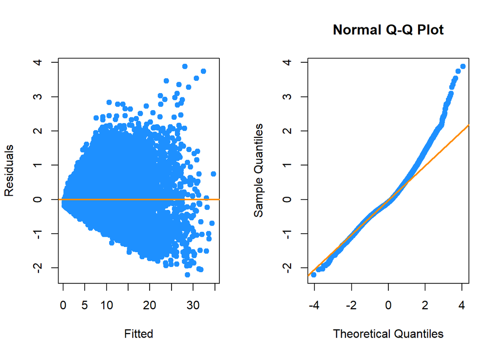

```r
plot_model(back_bic)
```

```r
get_loocv_rmse(back_bic)
```

```
## [1] 0.594
```

```r
get_adj_r2(back_bic)
```

```
## [1] 0.9898
```

```r
get_num_params(back_bic)
```

```
## [1] 4
```

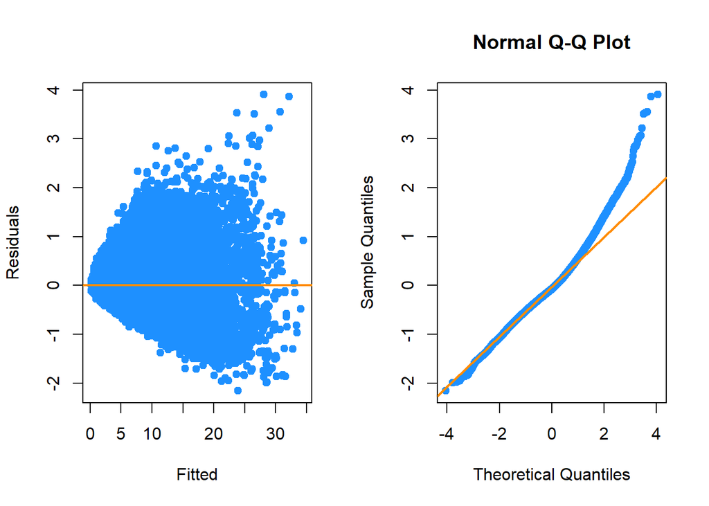

```r
plot_model(int_model)
```

```r
get_loocv_rmse(int_model)
```

```
## [1] 0.5917
```

```r
get_adj_r2(int_model)
```

```
## [1] 0.9899
```

```r
get_num_params(int_model)
```

```
## [1] 8
```

```r
anova(back_bic, int_model)
```

```
## Analysis of Variance Table
##
## Model 1: PTS ~ G + FG + FT
## Model 2: PTS ~ G * FG * FT
##   Res.Df  RSS Df Sum of Sq    F Pr(>F)
## 1  19308 6810
## 2  19304 6751  4      59.1 42.2 <2e-16 ***
## ---
## Signif. codes:  0 '***' 0.001 '**' 0.01 '*' 0.05 '.' 0.1 ' ' 1
```

## Discussion

Additionally, we explored an interaction model that considered interactions among Games Played (G), Field Goals (FG), and Free Throws (FT). The interaction model exhibited similar predictive performance to the backward BIC-selected model, with an adjusted R-squared value of approximately 0.9899.

Both the backward BIC-selected model and the interaction model yielded high adjusted R-squared values, indicating their ability to explain a substantial portion of the variance in player points per game. The root mean squared error (RMSE) for the backward BIC model was approximately 0.594, while the RMSE for the interaction model was slightly lower at approximately 0.5917. This suggests that both models are effective at predicting player performance.

The comparison of the two models using an analysis of variance (ANOVA) test revealed an extremely low p-value (2e-16), indicating that there is a significant difference between the models. However, given the minimal difference in predictive performance and the increased complexity of the interaction model (with twice the number of parameters), the simpler backward BIC-selected model might be preferable due to its more straightforward interpretation and reduced risk of overfitting.

In conclusion, our analysis of NBA player performance over time led us to construct two predictive models for player points per game. By employing systematic data preprocessing and model selection techniques, we pinpointed a concise model that highlights Games Played (G), Field Goals (FG), and Free Throws (FT) as the most influential factors in predicting player performance. This model exhibited strong predictive capabilities and a high degree of explanatory power. While the interaction model also performed well, the slight improvement in RMSE did not necessarily justify its increased complexity. Our findings highlight the importance of fundamental performance metrics and provide insights for coaches, analysts, and team managers seeking to optimize player selection and strategy based on historical trends.

## Appendix

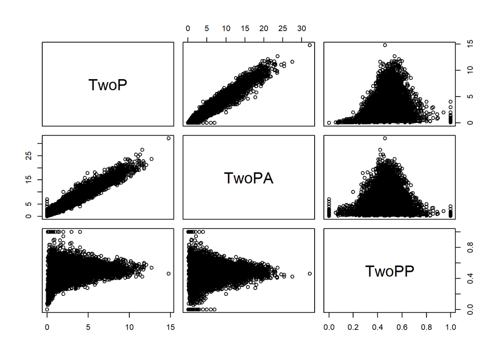

```r
two_pointers = raw_nba[, c("TwoP", "TwoPA", "TwoPP")]
pairs(two_pointers)
```

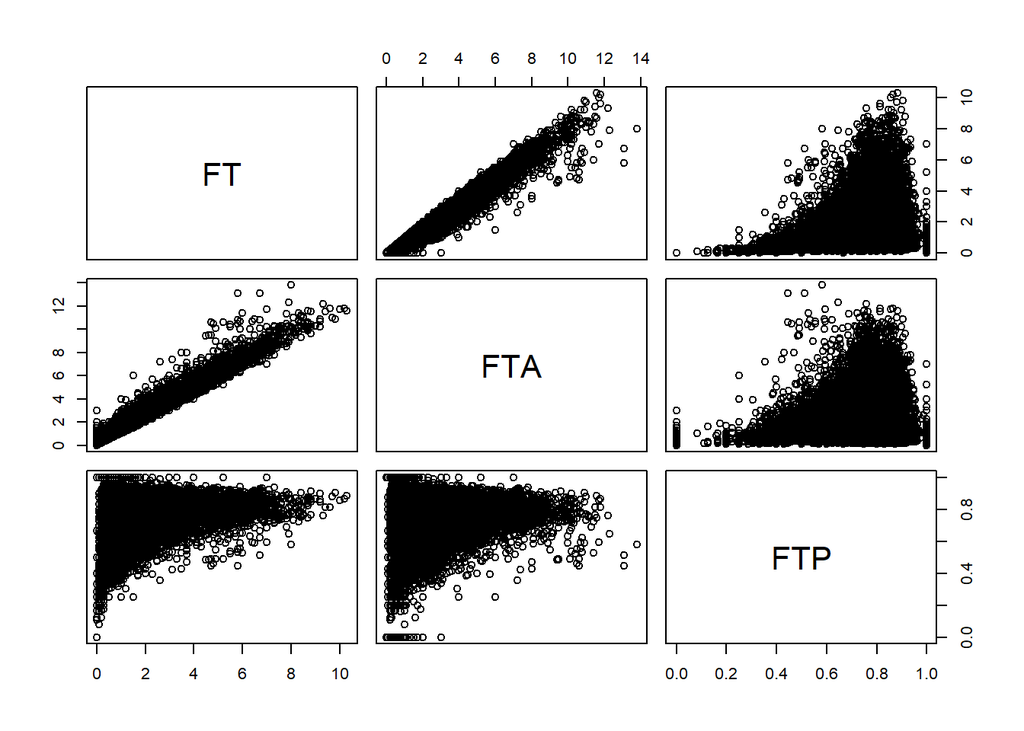

```r
free_throw = raw_nba[, c("FT", "FTA", "FTP")]
pairs(free_throw)
```

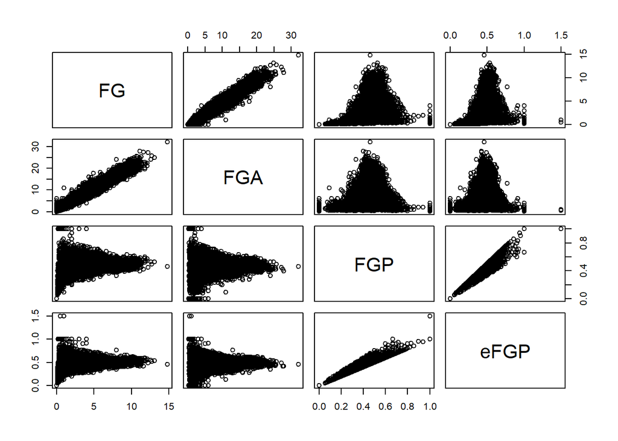

```r
field_goals = raw_nba[, c("FG", "FGA", "FGP", "eFGP")]
pairs(field_goals)
```

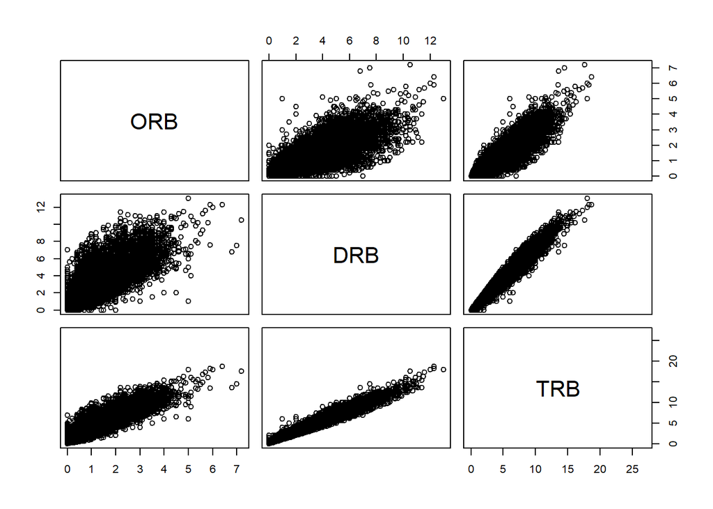

```r
rebounds = raw_nba[, c("ORB", "DRB", "TRB")]
pairs(rebounds)
```

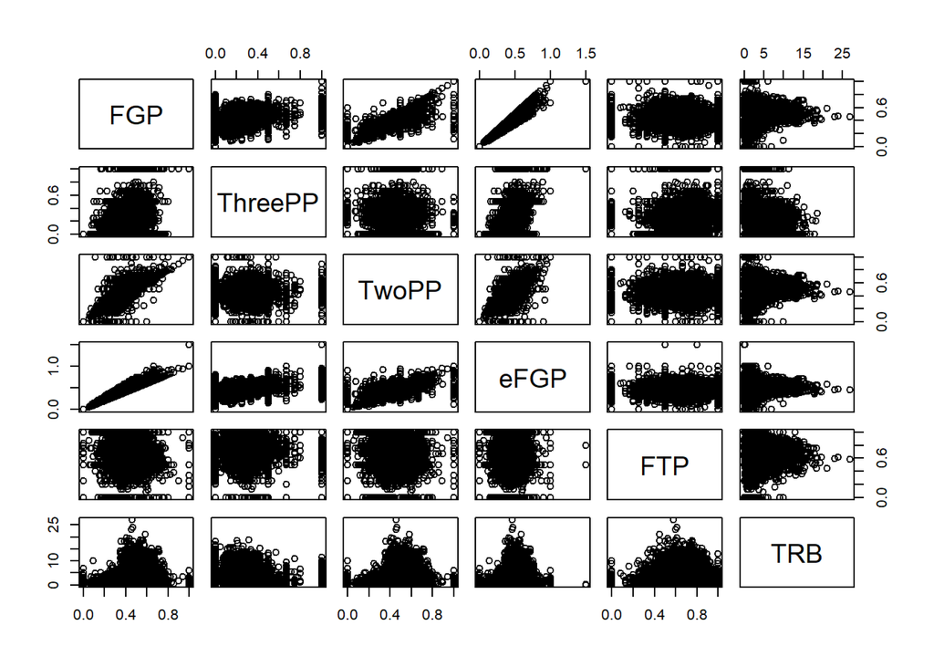

```r
percentage = raw_nba[, c("FGP", "ThreePP", "TwoPP", "eFGP", "FTP", "TRB")]
pairs(percentage)
```

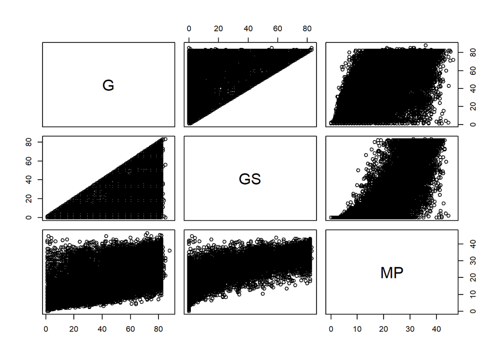

```r
games = raw_nba[, c("G", "GS", "MP")]
pairs(games)
```